# LTERWG SOM Data 101

Derek Pierson

November 9, 2018

# Getting Started

To start, let’s first load up the libraries we’ll be using here. Much of the data processing workflow here is done with dplyr. A helpful cheatsheet with common dplyr functions can be found here: https://www.rstudio.com/wp-content/uploads/2015/02/data-wrangling-cheatsheet.pdf

```r
#Load libraries
library(dplyr)
library(ggplot2)
```

### Loading The Data

**The compiled SOM data tarball can be found on our Google Drive [here](https://drive.google.com/drive/folders/1bQcTB8lZtE0vjuZ_kvPvDbHCyv0PLbt6?ogsrc=32)**

Let’s load in the compiled SOM data tarball .csv file and see what data columns we have to work with.

More info on the data columns can be found in the keykey master file located [here](https://drive.google.com/open?id=1kF-v3amzgqcjYXeJz7dfTgGuzb5xG0rY31Y1C6rR4kw) on the LTERWG Google Drive.

```r
#Change path to wherever you have the tarball.csv stored locally
data.all <- read.csv("E:/Box/Box Sync/SOM_tarball/tarball_10-18-2018.csv", stringsAsFactors = FALSE)

#Print out tarball column names
colnames(data.all)[1:30]  #only the first 30 in this case
```

```
##  [1] "X"                    "addit_contact_email"  "addit_contact_person"
##  [4] "author_email"         "author_PersonName"    "curator_email"
##  [7] "curator_organization" "curator_PersonName"   "elevation"
## [10] "google_id"            "header_row"           "lat"
## [13] "location_name"        "long"                 "modification_date"
## [16] "NA_1"                 "network"              "site_code"
## [19] "L2"                   "L3"                   "tx_L1"
## [22] "soc"                  "soc_stock"            "n_tot"
## [25] "n_tot_stock"          "layer_top"            "layer_bot"
## [28] "hzn"                  "bd_samp"              "ph_h2o"
```

### Unite site codes and location names

Currently, site identifiers exist in two columns, ‘location_name’ and ‘site code.’ To simplify data labels below, let combine those identifiers together into a new column called ‘full_name’.

```r
  data.all$full_name <- paste0(data.all$site_code," ",data.all$location_name)  #Concatenate strings
  data.all <- data.all %>% mutate(full_name = gsub("NA", "", full_name))  #Remove NA from strings
```

You can use the code `unique(data$full_name)` to see the full list of locations

# Filtering The Data

### By network

Using the ‘network’ column we can select data from a specific network

```r
  #View network names
  unique(data.all$network)
```

```
## [1] "LTER"   "DIRT"   "CZO"    "NutNet" "NEON"   NA
```

```r
  #Create a new dataframe with data from a specific network
  data.neon <- data.all %>% filter(network == "NEON")
```

### By depth

Here’s an example how to select the soil data from 0-10 cm

```r
  data.surf <- data.all %>% filter(layer_top == 0 & layer_bot == 10)
```

### By treatment level

```r
  #Take a look at names of level 1 treatments
  unique(data.all$tx_L1)[1:30]  #only showing the first 30
```

```
##  [1] "Undisturbed"                     "Disturbed"
##  [3] NA                                "c"
##  [5] "w"                               "Unmanaged"
##  [7] "Thinned"                         "Shearbladed"
##  [9] "Shearbladed, then ripper plowed" "DL"
## [11] "DW"                              "CTL"
## [13] "NI"                              "NL"
## [15] "NR"                              "DN"
## [17] "CO"                              "OA"
## [19] "BP"                              "PM"
## [21] "Control"                         "Double Litter"
## [23] "No Inputs"                       "No Litter"
## [25] "No Roots"                        "2"
## [27] "1"                               "hardwood"
## [29] "pine"                            "cultivated"
```

```r
  #Create vector of names to select for control or undisturbed sample locations
  ctls <- c("c","Undisturbed","Unmanaged","CTL","CO","Control")

  #Filter data by L1 treatment values = CONTROL or UNDISTURBED
  data.ctl <- data.all %>% filter(tx_L1 %in% ctls)
```

# Data Exploration Examples

### Data inventory tables

Create a dataframe table to show the number of values for ‘soc’ and ‘c_tot’ by location (‘full_name’)

```r
  data.ctbl <- data.all %>% group_by(full_name) %>% summarize(count.ctot = n_distinct(c_tot, na.rm = TRUE),
                                                              count.soc = n_distinct(soc, na.rm = TRUE))

  #Show the first 10 rows of the table
  data.ctbl[1:10,]
```

```
## # A tibble: 10 x 3
##    full_name                      count.ctot count.soc
##    <chr>                               <int>     <int>
##  1 " "                                   191       775
##  2 " Abiskojaure"                          0         0
##  3 " American Camp"                        0        30
##  4 " Antisana"                             0         0
##  5 " Archbold Biological Station"          0         0
##  6 " Azi"                                  0        29
##  7 " Bad Lauchstaedt"                      0        24
##  8 " Barta Brothers"                       0        29
##  9 " Bayreuth"                             0         0
## 10 " Bogong"                               0        30
```

Next let’s take a look at the number of experimental levels by location

```r
  data.explvls <- data.all %>% group_by(full_name) %>% summarize(L1_n = n_distinct(L1, na.rm = TRUE),
                                                                 L2_n = n_distinct(L2, na.rm = TRUE),
                                                                 L3_n = n_distinct(L3, na.rm = TRUE),
                                                                 L4_n = n_distinct(L4, na.rm = TRUE),
                                                                 L5_n = n_distinct(L5, na.rm = TRUE))
  #Show the first 10 rows of the table
  data.explvls[1:10,]
```

```
## # A tibble: 10 x 6
##    full_name                       L1_n  L2_n  L3_n  L4_n  L5_n
##    <chr>                          <int> <int> <int> <int> <int>
##  1 " "                               37   323  1517     0     0
##  2 " Abiskojaure"                     1    10    20     1     0
##  3 " American Camp"                   1     3    30     1     0
##  4 " Antisana"                        1     5    50     1     0
##  5 " Archbold Biological Station"     1     3    30     2     0
##  6 " Azi"                             1     3    30     5     0
##  7 " Bad Lauchstaedt"                 1     3    24     2     0
##  8 " Barta Brothers"                  1     3    30     4     0
##  9 " Bayreuth"                        1     3    30     1     0
## 10 " Bogong"                          1     3    30     9     0
```

# Plot Examples

### Filter data and create box plot by location

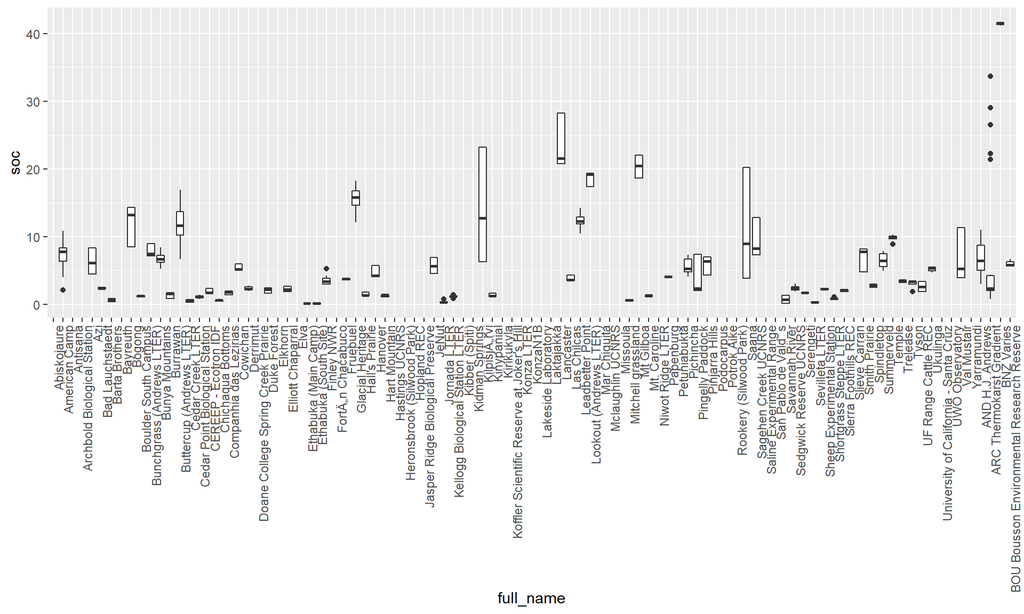

```r
  #Define the treatment classes to include. Only control type data in this case.
  ctls <- c("c","Undisturbed","Unmanaged","CTL","CO","Control")

  #Filter data by treatment and depth
  data.plot <- data.all %>% filter(tx_L1 %in% ctls) %>% filter(layer_top == 0 & layer_bot == 10) %>%
    select(full_name,location_name, site_code, soc, layer_top, layer_bot)  #Simplify the dataframe by selecting                                                                                                       only the columns we may need for                                                                                                          this plot/task

  #Create boxplot  (...may also by piped after the code above)
  soc.ctl.bxplot <- ggplot(data.plot, aes(x=full_name, y=soc)) + geom_boxplot() +
                    theme(axis.text.x = element_text(angle = 90, hjust = 1))  #Rotate x-axis labels
  soc.ctl.bxplot  #display plot
```

# Map Examples

### Currently we have to hotfix the latitude and longitude values to decimal degrees

A table with uniform decimal degree coordinates has been created to merge in with the raw compiled data. The ‘SOM_clean_coords.csv’ can be found [here](https://drive.google.com/open?id=1jdhUkP6G3FYQhEZDIYBN6sQ930bxsZp8)

```r
  #Bring in clean coordinate csv
  clean.coords <- read.csv("SOM_clean_coords.csv", stringsAsFactors = FALSE)

  #Remove duplicate lat & long values to avoid adding rows in join step
  lat.clean <- clean.coords %>% distinct(lat, lat.clean)
  long.clean <- clean.coords %>% distinct(long, long.clean)

  #Join clean coordinate columns to tarball dataframe
  data.all <- left_join(data.all, lat.clean, by="lat") %>% left_join(., long.clean, by="long")
```

The uniform, aka “clean” coordinates are now added to the end of the dataframe as ‘lat.clean’ and ‘long.clean’

### Simple point map

Here’s an example of a simple line and point map showing sites included in the dataset

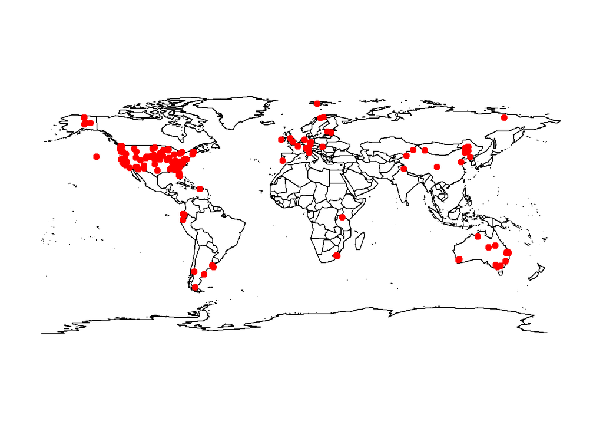

```r
library(maps)

  map('world')
  points(data.all$long.clean, data.all$lat.clean, col=2, pch=19)
```

### Filter data and create map of mean 0-10 cm SOC for undistrubed soils only

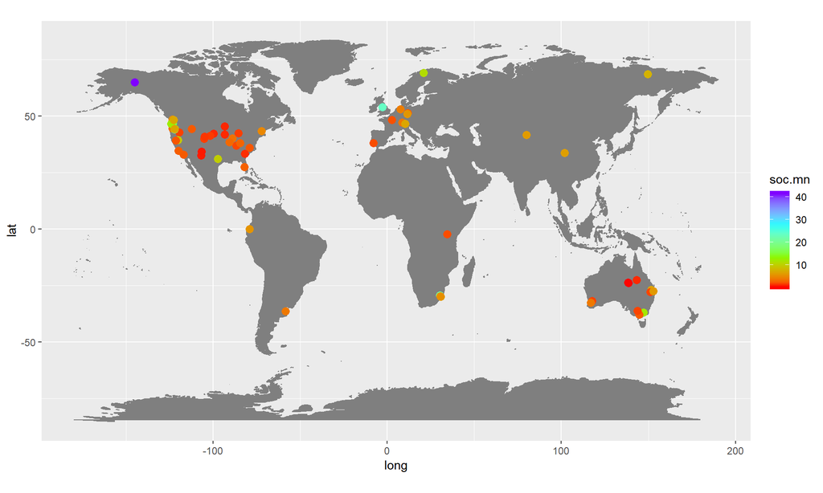

```r
library('ggmap')

  #Starting with the merged clean lat, long dataframe from above (...still named data.all)
  #Also using the defined 'ctls' from above to select undisturbed soils only
  data.map <- data.all %>% filter(tx_L1 %in% ctls) %>% filter(layer_top == 0 & layer_bot == 10) %>%
    select(full_name,location_name, site_code, soc, layer_top, layer_bot, lat.clean, long.clean)


  #Summarize data to find n, mean, st dev, min, and max soc values by location
  data.map.soc <- data.map %>% distinct(full_name,soc,lat.clean,long.clean) %>%  #Remove duplicate rows
                                filter(!is.na(soc)) %>%  #Remove rows with NA for soc
                                group_by(full_name) %>%   #To summarize the data by location, first we need                                                                                          to group it by location
                                summarise(soc.count = n(),  #Summarise creates new dataframe with desired                                                                                              group statistics
                                          soc.mn = mean(soc, na.rm = T),
                                          soc.stdv = sd(soc, na.rm = T),
                                          soc.min = min(soc, na.rm = T),
                                          soc.max = max(soc, na.rm = T),
                                          lat = first(lat.clean),  #Isolate coordinates within the summary                                                                                                    call, grabs the first value in the group
                                          long = first(long.clean))


  #Map it
  mapWorld <- borders("world", colour="gray50", fill="gray50") # Create the world map
  ggplot() + mapWorld + geom_point(data = data.map.soc, aes(x=long, y = lat, color=soc.mn), size=3) +
    coord_fixed(1.3) +  #Ensure the coordinates points are projected correctly
    scale_colour_gradientn(colours=rainbow(4))  #Expand the color scale
```